# Step1 asSeq QC

## 1. Total number of reads (TReC) per sample versus the total number of allele-specific reads (ASE) per sample

### 1.1 Read in Total read counts

```r
library(ggplot2)
library(scales)

proj_input = "../R_batch1/stepC_collect_read_count/output"
ASCN_input = '..'
step5_file = "gene_level_counts_filterIt_total_after_filter_low_expressed_gene.txt"
step4a_file = "gene_level_counts_filterIt_hap1.txt"
step4b_file = "gene_level_counts_filterIt_hap2.txt"

TReC = read.table(file = sprintf("%s/step5_TReC_per_gene_filterIt/%s",proj_input,step5_file),
                  as.is = T, sep = "\t", check.names = F)
TReC = data.matrix(TReC)
dim(TReC)
```

```
## [1] 21803   511
```

```r
TReC[1:5,1:5]
```

```
##                    TCGA-3L-AA1B-01A TCGA-4N-A93T-01A TCGA-4T-AA8H-01A
## ENSG00000000003.14             7311             7180             2967
## ENSG00000000005.5                23               66               84
## ENSG00000000419.12             2072             2645              843
## ENSG00000000457.13             1266             1306              500
## ENSG00000000460.16              934              774              375
##                    TCGA-5M-AAT4-01A TCGA-5M-AAT5-01A
## ENSG00000000003.14            10019             5380
## ENSG00000000005.5                87              189
## ENSG00000000419.12             2557             4217
## ENSG00000000457.13             1341             1212
## ENSG00000000460.16             1344             1254
```

### 1.2 Read in allele-specific copy number

```r
ASCN = readRDS(sprintf('%s/data/TCGA_SCNA/COAD_ASCAT_by_gene.rds', ASCN_input))
ASCN$CN1[1:5,1:5]
```

```
##                    TCGA-3L-AA1B-01A-11D-A36W-01_TCGA-3L-AA1B-10A-01D-A36Z-01
## ENSG00000000003.14                                                        NA
## ENSG00000000005.5                                                         NA
## ENSG00000000419.12                                                         3
## ENSG00000000457.13                                                         1
## ENSG00000000460.16                                                         1
##                    TCGA-4N-A93T-01A-11D-A36W-01_TCGA-4N-A93T-10A-01D-A36Z-01
## ENSG00000000003.14                                                        NA
## ENSG00000000005.5                                                         NA
## ENSG00000000419.12                                                         1
## ENSG00000000457.13                                                         1
## ENSG00000000460.16                                                         1
##                    TCGA-4T-AA8H-01A-11D-A40O-01_TCGA-4T-AA8H-10B-01D-A40O-01
## ENSG00000000003.14                                                        NA
## ENSG00000000005.5                                                         NA
## ENSG00000000419.12                                                         1
## ENSG00000000457.13                                                         1
## ENSG00000000460.16                                                         1
##                    TCGA-5M-AAT4-01A-11D-A40O-01_TCGA-5M-AAT4-10A-01D-A40O-01
## ENSG00000000003.14                                                        NA
## ENSG00000000005.5                                                         NA
## ENSG00000000419.12                                                         2
## ENSG00000000457.13                                                         1
## ENSG00000000460.16                                                         1
##                    TCGA-5M-AAT5-01A-21D-A40O-01_TCGA-5M-AAT5-10A-01D-A40O-01
## ENSG00000000003.14                                                        NA
## ENSG00000000005.5                                                         NA
## ENSG00000000419.12                                                         3
## ENSG00000000457.13                                                         3
## ENSG00000000460.16                                                         3
```

```r
gene2kp = intersect(rownames(TReC), rownames(ASCN$CN1))
length(gene2kp)
```

```
## [1] 19172
```

```r
ASCN$CN1 = ASCN$CN1[gene2kp, ]
ASCN$CN2 = ASCN$CN2[gene2kp, ]
TReC = TReC[gene2kp, ]
```

### 1.3 Read in allele-specific read counts

```r
ASE1 = read.table(sprintf("%s/step4a_ASReC_per_gene_hap1_filterIt/%s", proj_input, step4a_file),
                  sep ='\t', header = T, check.names = F)
ASE1 = data.matrix(ASE1)
ASE1[1:5,1:5]
```

```
##                    TCGA-3L-AA1B-01A_asCounts_hetSNP_filterIt_hap1.bam
## ENSG00000000003.14                                                  0
## ENSG00000000005.5                                                   0
## ENSG00000000419.12                                                  0
## ENSG00000000457.13                                                 11
## ENSG00000000460.16                                                  0
##                    TCGA-4N-A93T-01A_asCounts_hetSNP_filterIt_hap1.bam
## ENSG00000000003.14                                                  0
## ENSG00000000005.5                                                   0
## ENSG00000000419.12                                                  0
## ENSG00000000457.13                                                 67
## ENSG00000000460.16                                                 20
##                    TCGA-4T-AA8H-01A_asCounts_hetSNP_filterIt_hap1.bam
## ENSG00000000003.14                                                  0
## ENSG00000000005.5                                                   0
## ENSG00000000419.12                                                  0
## ENSG00000000457.13                                                  0
## ENSG00000000460.16                                                  0
##                    TCGA-5M-AAT4-01A_asCounts_hetSNP_filterIt_hap1.bam
## ENSG00000000003.14                                                  0
## ENSG00000000005.5                                                   0
## ENSG00000000419.12                                                  0
## ENSG00000000457.13                                                 17
## ENSG00000000460.16                                                 16
##                    TCGA-5M-AAT5-01A_asCounts_hetSNP_filterIt_hap1.bam
## ENSG00000000003.14                                                  0
## ENSG00000000005.5                                                   0
## ENSG00000000419.12                                                  0
## ENSG00000000457.13                                                 29
## ENSG00000000460.16                                                  6
```

```r
ASE2 = read.table(sprintf("%s/step4b_ASReC_per_gene_hap2_filterIt/%s", proj_input, step4b_file),
                  sep ='\t', header = T, check.names = F)
ASE2 = data.matrix(ASE2)


ASE1= ASE1[gene2kp, ]
ASE2 = ASE2[gene2kp, ]
ASEtot = (ASE1 + ASE2)
ASEtot[ASEtot <20] = NA

colnames(ASE1) = substr(colnames(ASE1), 1, 16)
colnames(ASE2) = substr(colnames(ASE2), 1, 16)
table(colnames(ASE1) == colnames(ASE2))
```

```
##
## TRUE
##  468
```

```r
TReC <- TReC[,colnames(ASE2)]

ASEt =  apply(ASEtot, 2, sum, na.rm = T)
TReCt = apply(TReC, 2, sum, na.rm = T)

n_gene_ASE_per_sam = apply(ASEtot, 2, function(x) sum(!is.na(x)))
pASE1 = ASE1/ASEtot
pASE1_bi0.1 = apply(pASE1, 2, function(x) sum(x < 0.1 | x>0.9 , na.rm = T) ) / n_gene_ASE_per_sam

plot_data = data.frame(log10TReCt = log10(TReCt), log10ASEt = log10(ASEt),
                       n_gene_ASE_per_sam, pASE1_bi0.1)
```

### 1.4 TReC vs ASE

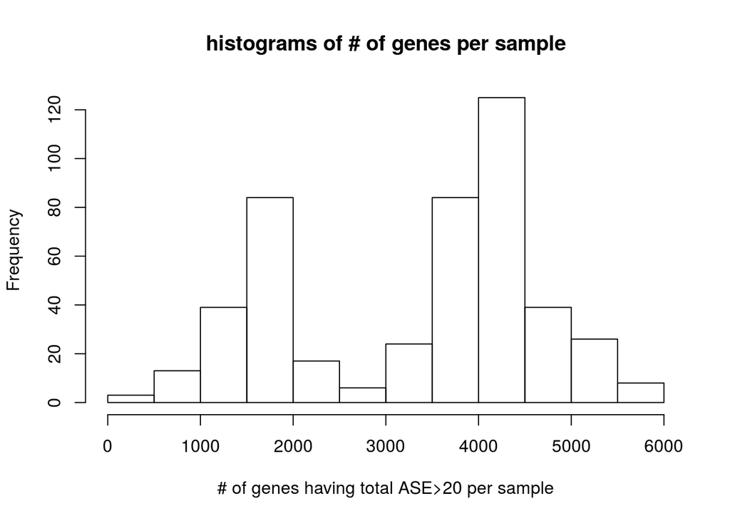

```r
hist(n_gene_ASE_per_sam, xlab = '# of genes having total ASE>20 per sample',
     main = 'histograms of # of genes per sample')
```

There is bimodal in the above histogram of numbers of genes have total allele-specific reads large than 20 and it shows that there are two cluster of people, one with larger number of genes than another cluster.

In the following scatter-plot of total number of reads per sample versus the total number of allele-specific reads per sample, 2500 genes is used as a cut-off and two clusters can be clearly seen. There are three points ( ‘TCGA-A6-3810-01A’, ‘TCGA-A6-2684-01A’, ‘TCGA-A6-2674-01A’) have unexpected low total allele-specific reads, and they are exluded in the further analysis.

We define the pASE1 to be proportion of allele-specific reads of allele 1 over total allele-specific reads and define the extreme pASE to be proportion of pASE1 having value between 0 to 0.1 or between 0.9 to 1.

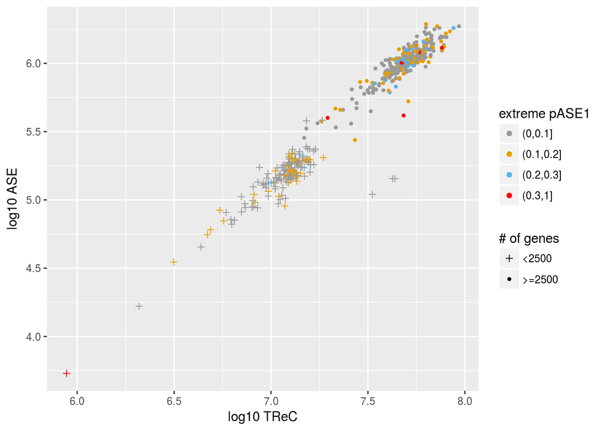

```r
ggplot(plot_data, aes(log10TReCt, log10ASEt,
       shape = cut(n_gene_ASE_per_sam, breaks = c(0, 2500,max(n_gene_ASE_per_sam + 1)), right = F),
       color = cut(pASE1_bi0.1, breaks = c(0, 0.1, 0.2, 0.3, 1)))) +
  geom_point() + labs(color = 'extreme pASE1', x = 'log10 TReC', y = 'log10 ASE') +
  scale_shape_manual(values=c(3, 20), name = '# of genes', labels=c('<2500','>=2500')) +
  scale_color_manual(values=c('#999999','#E69F00', '#56B4E9','red'))
```

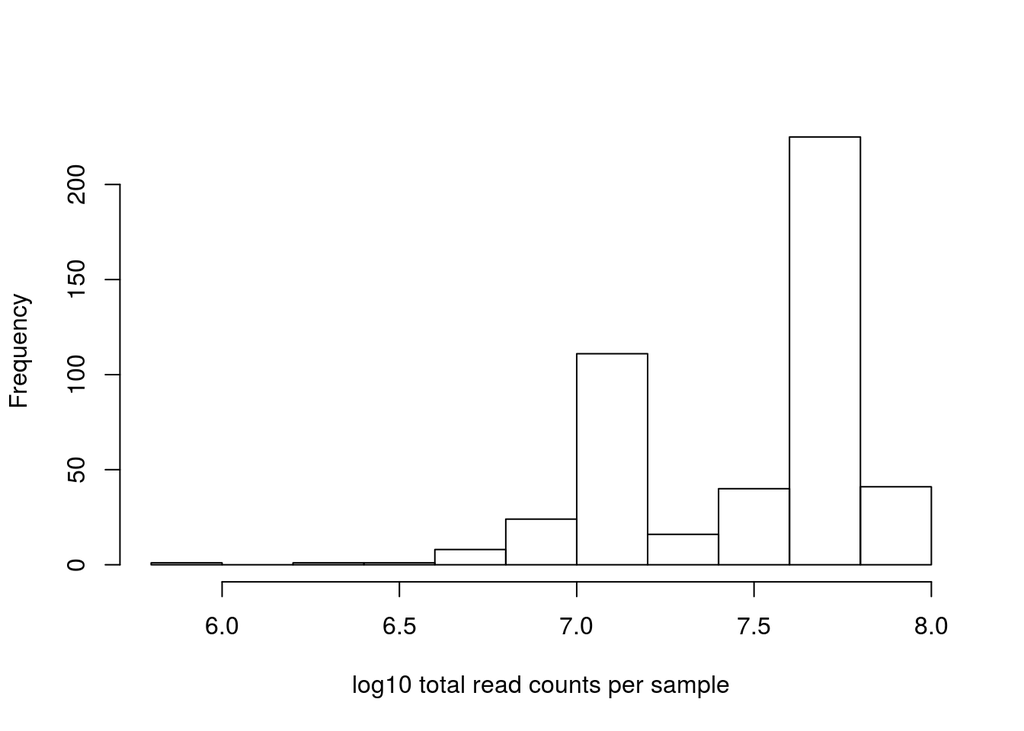

```r
hist(plot_data$log10TReCt, xlab = "log10 total read counts per sample", main = "")
```

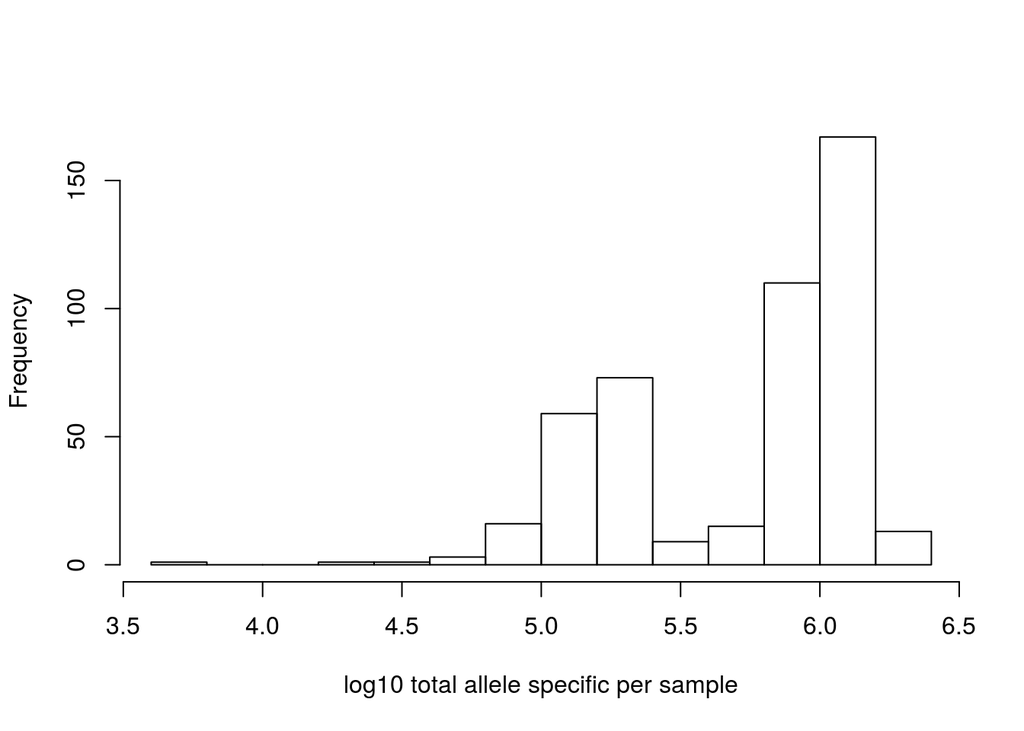

```r
hist(plot_data$log10ASEt, xlab = "log10 total allele specific per sample", main = "")
```

### 1.5 Remove outliers and duplicated samples

```r
outlier = c('TCGA-A6-3810-01A', 'TCGA-A6-2684-01A', 'TCGA-A6-2674-01A')
ind = which(colnames(ASE1) %in% outlier)
ASE1 = ASE1[, -ind]
ASE2 = ASE2[, -ind]

samASE = substr(colnames(ASE1), 1, 12)

# keep primary tumor
vial = substr(colnames(ASE1), 14, 16)
sam2kp = grep('01', vial)


ASE1 = ASE1[,sam2kp]
ASE2 = ASE2[,sam2kp]

samASE = substr(colnames(ASE1), 1, 12)
tp = table(samASE)

TReC = TReC[, colnames(ASE1)]
TReCt = apply(TReC, 2, sum, na.rm = T)


samASE = substr(colnames(ASE1), 1, 12)
tp = table(samASE)

vial = substr(colnames(ASE1), 14, 16)

samASCN = substr(colnames(ASCN$CN1), 1, 16)
samASCN[1:5]
```

```
## [1] "TCGA-3L-AA1B-01A" "TCGA-4N-A93T-01A" "TCGA-4T-AA8H-01A"
## [4] "TCGA-5M-AAT4-01A" "TCGA-5M-AAT5-01A"
```

```r
samASE = substr(colnames(ASE1), 1, 16)


sam2kp = intersect(samASCN, samASE)
length(sam2kp)
```

```
## [1] 420
```

```r
ind3 = match(sam2kp, samASCN)

ASCN$CN1 = ASCN$CN1[, ind3]
ASCN$CN2 = ASCN$CN2[, ind3]
ASE1 = ASE1[, match(sam2kp, samASE)]
ASE2 = ASE2[, match(sam2kp, samASE)]
TReC = TReC[, colnames(ASE2)]

ASEtot = (ASE1 + ASE2)
ASEtot[ASEtot <20] = NA

n_sam_ASE_per_gene= apply(ASEtot, 1, function(x) sum(!is.na(x)))
n_gene_ASE_per_sam = apply(ASEtot, 2, function(x) sum(!is.na(x)))

pASE1 = ASE1/ASEtot
pASE1_bi0.1 = apply(pASE1, 2, function(x)
  sum(x < 0.1 | x>0.9 , na.rm = T) ) / n_gene_ASE_per_sam

pASE1_bi0.2 = apply(pASE1, 2, function(x)
  sum((x < 0.2 & x>0.1) | (x>0.8 & x<0.9) , na.rm = T) ) / n_gene_ASE_per_sam


TReC = TReC[, colnames(ASE1)]
table(colnames(TReC) == colnames(ASE1))
```

```
##
## TRUE
##  420
```

```r
ASEt =  apply(ASEtot, 2, sum, na.rm = T)
TReCt = apply(TReC, 2, sum, na.rm = T)
cor(ASEt, TReCt)
```

```
## [1] 0.9659964
```

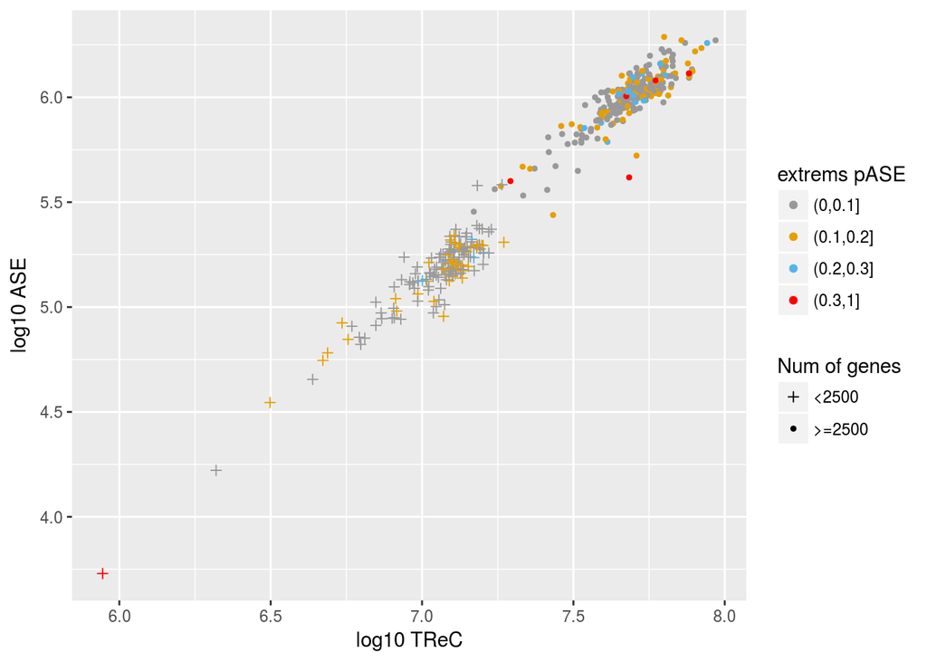

```r
n_gene_ASE_per_sam = apply(ASEtot, 2, function(x) sum(!is.na(x)))
pASE1 = ASE1/ASEtot
pASE1_bi0.1 = apply(pASE1, 2, function(x)
  sum(x < 0.1 | x>0.9 , na.rm = T) ) / n_gene_ASE_per_sam

plot_data = data.frame(log10TReCt = log10(TReCt), log10ASEt = log10(ASEt),
                       n_gene_ASE_per_sam, pASE1_bi0.1)

ggplot(plot_data, aes(log10TReCt, log10ASEt,
       shape = cut(n_gene_ASE_per_sam, breaks = c(0, 2500,max(n_gene_ASE_per_sam + 1)), right = F),
       color = cut(pASE1_bi0.1, breaks = c(0, 0.1, 0.2, 0.3, 1)))) +
  geom_point() + labs(color = 'extrems pASE', x = 'log10 TReC', y = 'log10 ASE') +
  scale_shape_manual(values=c(3, 20), name = 'Num of genes', labels=c('<2500','>=2500')) +
  scale_color_manual(values=c('#999999','#E69F00', '#56B4E9','red'))
```

After removing the outliers and duplicated samples, we redraw the scatter-plot of total number of reads per sample versus the total number of allele-specific reads per sample.

## 2. Copy number variation consideration

### 2.1 Before remove copy number altered genes

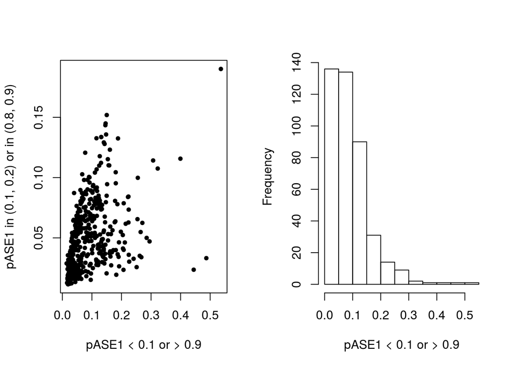

```r
par(mfrow=c(1,2))
plot(pASE1_bi0.1, pASE1_bi0.2, xlab = 'pASE1 < 0.1 or > 0.9'
     , ylab = 'pASE1 in (0.1, 0.2) or in (0.8, 0.9)', pch = 20)
# abline(v = 0.3, col = 2, lty =2)
hist(pASE1_bi0.1, xlab = 'pASE1 < 0.1 or > 0.9', main ='')
```

```r
# abline(v = 0.3, col = 2)
```

### 2.2 After remove copy number altered genes

Gene with Allele-specific copy number other than (1,1) or (2,2) are removed.

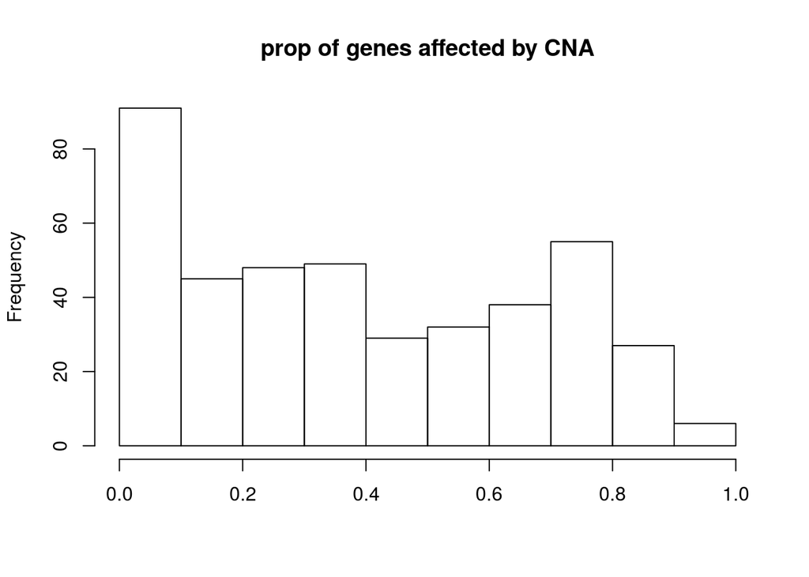

```r
ASEtot_rm= ASEtot
AStot = ASCN$CN1 + ASCN$CN2

ASEtot_rm = data.matrix(ASEtot_rm)
ASEtot_rm[is.na(ASCN$CN1) | is.na(ASCN$CN2) | (AStot) > 4] <- NA
ASEtot_rm[(ASCN$CN1 != ASCN$CN2) ] <- NA

ASEt =  apply(ASEtot_rm, 2, sum, na.rm = T)

n_gene_ASE_per_sam_rm= apply(ASEtot_rm, 2, function(x) sum(!is.na(x)))

pASE1_rm = ASE1/ASEtot_rm
pASE1_bi0.1_rm = apply(pASE1_rm, 2, function(x)
  sum(x < 0.1 | x>0.9 , na.rm = T) ) / n_gene_ASE_per_sam_rm

pASE1_bi0.2_rm = apply(pASE1_rm, 2, function(x)
  sum((x < 0.2 & x>0.1) | (x>0.8 & x<0.9), na.rm = T) ) / n_gene_ASE_per_sam_rm

NgeneAlter = (n_gene_ASE_per_sam - n_gene_ASE_per_sam_rm)/ n_gene_ASE_per_sam

hist(NgeneAlter, main = 'prop of genes affected by CNA', xlab = '')
```

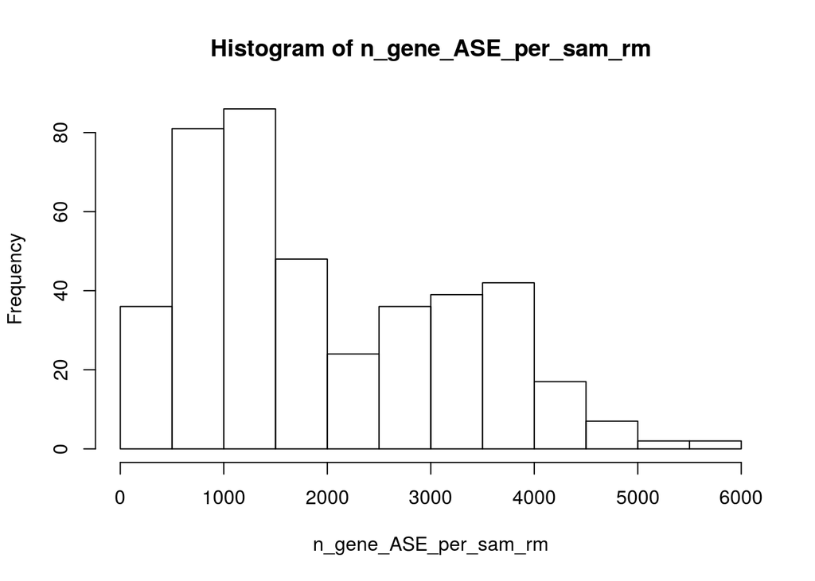

```r
col = rep(1, length(n_gene_ASE_per_sam_rm))
col[which(n_gene_ASE_per_sam_rm < 50)] = 2
hist(n_gene_ASE_per_sam_rm)
```

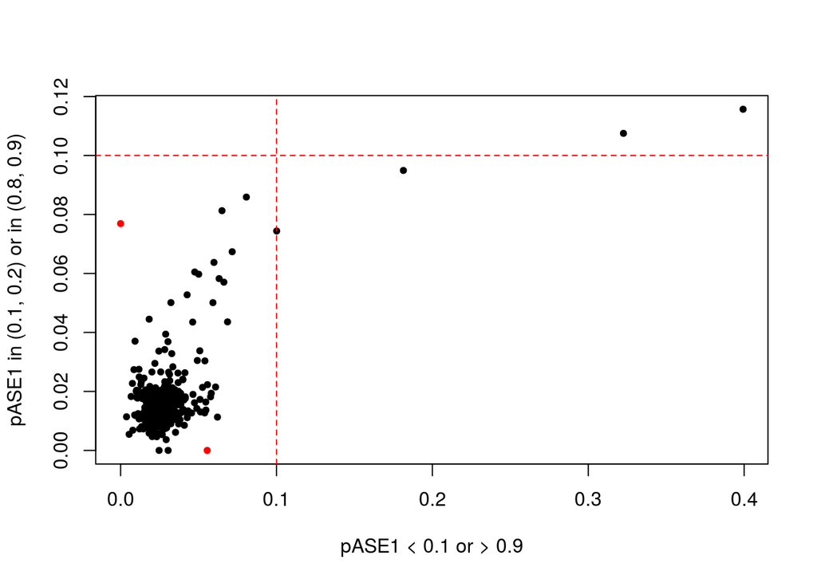

```r
plot(pASE1_bi0.1_rm, pASE1_bi0.2_rm, xlab = 'pASE1 < 0.1 or > 0.9'
     , ylab = 'pASE1 in (0.1, 0.2) or in (0.8, 0.9)', pch = 20, col = col)
abline(v = 0.1, col = 2, lty = 2)
abline(h = 0.1, col = 2, lty = 2)
```

The red points indicates a sample having number of genes less than 50 after removed the copy number altered genes.

- Sample with more than 50 genes is removed in the following analysis if it meet one of the following conditions:
  - proportion of pASE, between 0.1 to 0.2 or 0.8 to 0.9, is larger than 0.1, or
  - proportion of pASE, less than 0.1 or larger than 0.9, is larger than 0.1.
- Sample with less than 50 genes will be further examined in scatter-plot of pASCN (minor copy number/total copy number) versus pASE (low AS read counts/total AS read counts).

```r
sams2rm =  names(which((pASE1_bi0.2_rm > 0.1 | pASE1_bi0.1_rm > 0.1 ) & n_gene_ASE_per_sam_rm > 50))
sams2rm
```

```
## [1] "TCGA-A6-3809-01B" "TCGA-A6-5659-01B" "TCGA-A6-5661-01B"
## [4] "TCGA-CM-4748-01A"
```

```r
samASE =substr(setdiff(colnames(TReC), sams2rm), 1, 12)
sam2check = samASE[which(duplicated(samASE))]
for(s in sam2check){
  tr = TReCt[grep(s, colnames(TReC))]
  sams2rm = c(sams2rm, names(which.min(tr)))
}
sams2rm
```

```
##  [1] "TCGA-A6-3809-01B" "TCGA-A6-5659-01B" "TCGA-A6-5661-01B"
##  [4] "TCGA-CM-4748-01A" "TCGA-A6-2672-01A" "TCGA-A6-2677-01A"
##  [7] "TCGA-A6-5656-01B" "TCGA-A6-5665-01B" "TCGA-A6-6650-01B"
## [10] "TCGA-A6-6780-01B" "TCGA-A6-6781-01B"
```

```r
write.table(setdiff(colnames(TReC), sams2rm),
            file = '/fh/fast/sun_w/licai/_tumor_eQTL/R_batch2/samples_to_include.txt',
            quote = F, row.names = F, col.names = F)
```

## 3. Compare TCGA COAD to GTEx

```r
inputdir = "/fh/fast/sun_w/licai/_GTEx/R_batch2/stepC/output/"
step4a   = "step4a_ASReC_per_gene_hap1_filterIt"
step4b   = "step4b_ASReC_per_gene_hap2_filterIt"
step5    =  "step5_TReC_per_gene_filterIt"
geno_dir = "/fh/fast/sun_w/licai/_GTEx/data_genotype/genotype"
step5_file = "gene_level_counts_filter_out_low_expressed.txt"
step4a_file = "gene_level_counts_filterIt_hap1.txt"
step4b_file = "gene_level_counts_filterIt_hap2.txt"

setwd(inputdir)

TReC_gtex = read.table(sprintf("./%s/%s",step5, step5_file), as.is = T, sep="\t",
                  check.names = F)
TReC_gtex = data.matrix(TReC_gtex)
dim(TReC_gtex)
```

```
## [1] 21300   180
```

```r
TReC_gtex[1:5,1:5]
```

```
##                    GTEX-111CU GTEX-111VG GTEX-111YS GTEX-1122O GTEX-1128S
## ENSG00000000003.14       3510        780        494       3260       2777
## ENSG00000000005.5          12         14          4         41         13
## ENSG00000000419.12        950        690        636        582        697
## ENSG00000000457.13        684        546        652        818        778
## ENSG00000000460.16        360        311        349        333        533
```

```r
ASE1_gtex = read.table(sprintf("./%s/%s", step4a, step4a_file), as.is = T,
                  sep = "\t", check.names = F)
ASE1_gtex = data.matrix(ASE1_gtex)
colnames(ASE1_gtex) = gsub("_$", "", substr(colnames(ASE1_gtex), 1, 10))
ASE1_gtex = ASE1_gtex[rownames(TReC_gtex), colnames(TReC_gtex)]
dim(ASE1_gtex)
```

```
## [1] 21300   180
```

```r
ASE1_gtex[1:5,1:5]
```

```
##                    GTEX-111CU GTEX-111VG GTEX-111YS GTEX-1122O GTEX-1128S
## ENSG00000000003.14          0          0          0          0          0
## ENSG00000000005.5           0          0          0          0          0
## ENSG00000000419.12          0          0          0          0          0
## ENSG00000000457.13         27         69         30         51         63
## ENSG00000000460.16          3         14          6          3         30
```

```r
ASE2_gtex = read.table(sprintf("./%s/%s", step4b, step4b_file), as.is = T,
                  sep = "\t", check.names = F)
colnames(ASE2_gtex) = gsub("_$", "", substr(colnames(ASE2_gtex), 1, 10))
ASE2_gtex = data.matrix(ASE2_gtex)
ASE2_gtex = ASE2_gtex[rownames(TReC_gtex), colnames(TReC_gtex)]
dim(ASE2_gtex)
```

```
## [1] 21300   180
```

```r
ASE2_gtex[1:5,1:5]
```

```
##                    GTEX-111CU GTEX-111VG GTEX-111YS GTEX-1122O GTEX-1128S
## ENSG00000000003.14          0          0          0          0          0
## ENSG00000000005.5           0          0          0          0          0
## ENSG00000000419.12          0          0          0          0          0
## ENSG00000000457.13         27         76         39         43         63
## ENSG00000000460.16          2         24         10          5         35
```

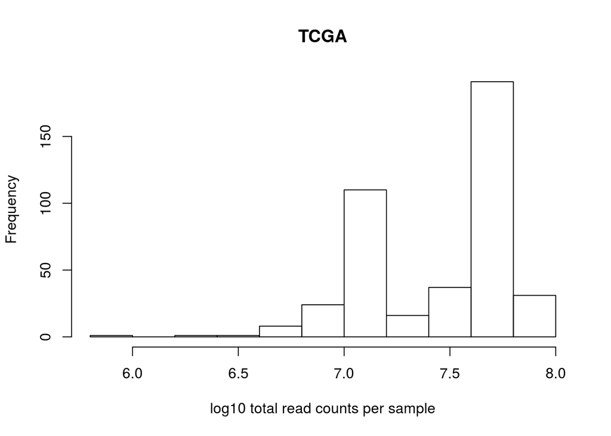

```r
ASEtot_gtex = (ASE1_gtex + ASE2_gtex)
ASEtot_gtex[ASEtot_gtex <20] = NA


ASEt =  apply(ASEtot_gtex, 2, sum, na.rm = T)
TReCt = apply(TReC_gtex, 2, sum, na.rm = T)

n_gene_ASE_per_sam_gtex = apply(ASEtot_gtex, 2, function(x) sum(!is.na(x)))
pASE1_gtex = ASE1_gtex/ASEtot_gtex
pASE1_bi0.1_gtex = apply(pASE1_gtex, 2, function(x) sum(x < 0.1 | x>0.9 , na.rm = T) ) / n_gene_ASE_per_sam_gtex

plot_data2 = data.frame(log10TReCt = log10(TReCt), log10ASEt = log10(ASEt),
                       n_gene_ASE_per_sam = n_gene_ASE_per_sam_gtex,
                       pASE1_bi0.1 = pASE1_bi0.1_gtex)

hist(plot_data$log10TReCt, xlab = "log10 total read counts per sample", main = "TCGA")
```

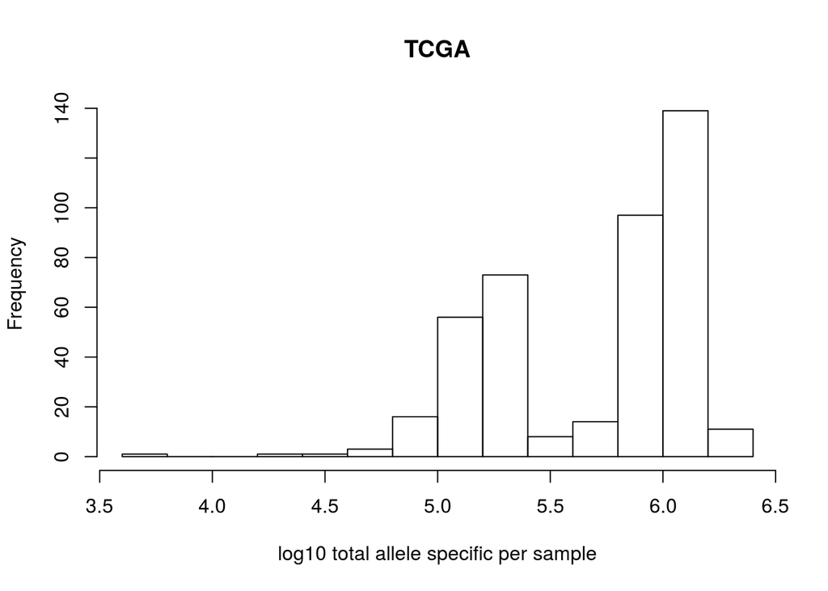

```r
hist(plot_data$log10ASEt, xlab = "log10 total allele specific per sample", main = "TCGA")
```

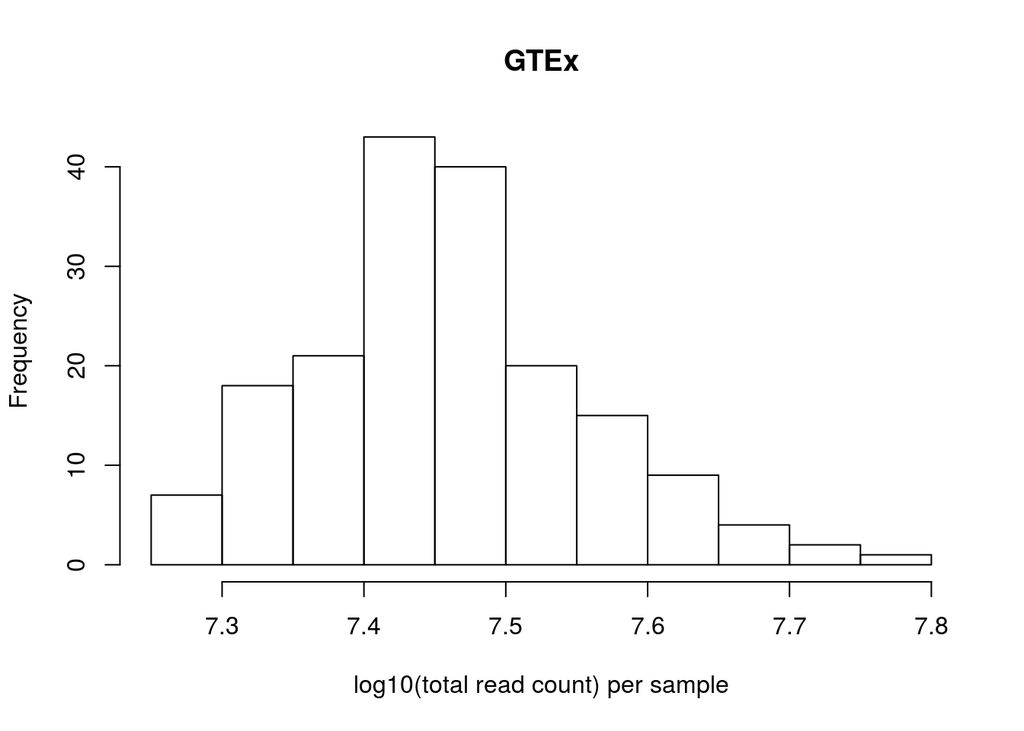

```r
hist(plot_data2$log10TReCt,
     xlab = 'log10(total read count) per sample', main = "GTEx")
```

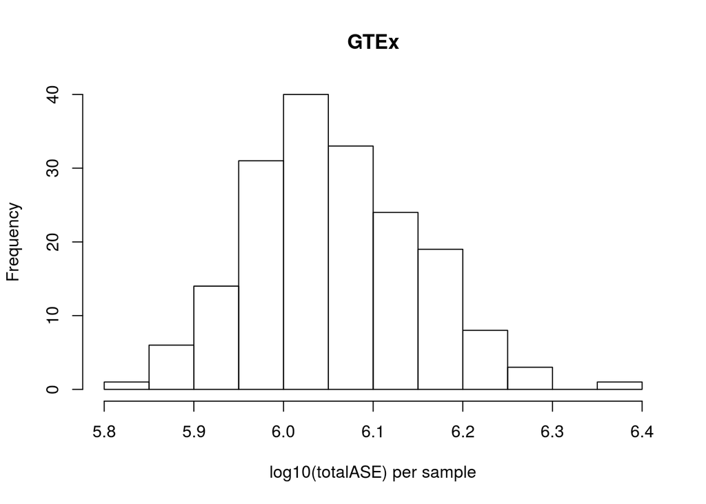

```r
hist(plot_data2$log10ASEt,
     xlab = 'log10(totalASE) per sample', main = "GTEx")
```

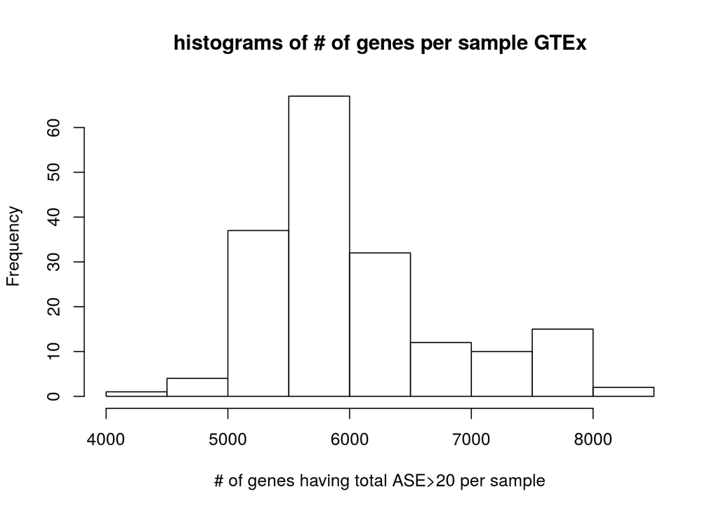

```r
hist(n_gene_ASE_per_sam_gtex, xlab = '# of genes having total ASE>20 per sample',
     main = 'histograms of # of genes per sample GTEx')
```

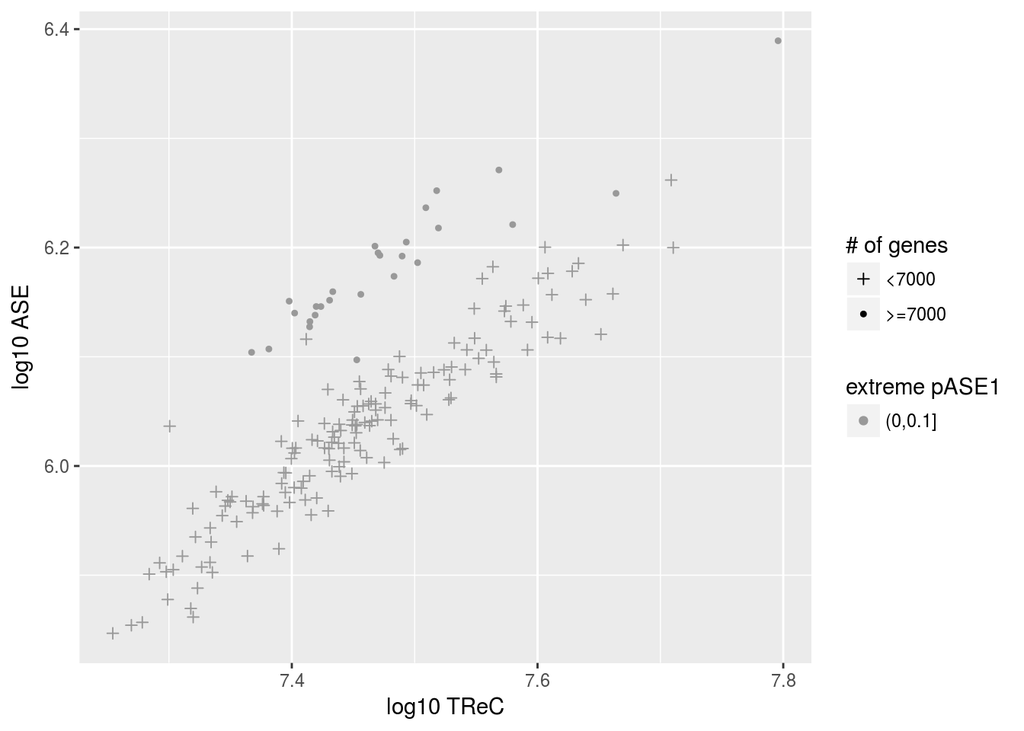

```r
ggplot(plot_data2, aes(log10TReCt, log10ASEt,
       shape = cut(n_gene_ASE_per_sam_gtex, breaks = c(0,7000 ,max(n_gene_ASE_per_sam_gtex + 1)), right = F),
       color = cut(pASE1_bi0.1_gtex, breaks = c(0, 0.1, 0.2, 0.3, 1)))) +
  geom_point() + labs(color = 'extreme pASE1', x = 'log10 TReC', y = 'log10 ASE') +
  scale_shape_manual(values=c(3, 20), name = '# of genes', labels=c('<7000','>=7000')) +
  scale_color_manual(values=c('#999999','#E69F00', '#56B4E9','red'))
```

```r
plot_data_all = rbind(cbind(plot_data, study ="TCGA"), cbind(plot_data2, study ="GTEx"))
plot_data_all[1:5,]
```

```
##                  log10TReCt log10ASEt n_gene_ASE_per_sam pASE1_bi0.1 study
## TCGA-3L-AA1B-01A   7.685995  6.048045               5488  0.04008746  TCGA
## TCGA-4N-A93T-01A   7.712917  6.101956               4988  0.24097835  TCGA
## TCGA-4T-AA8H-01A   7.525933  5.848272               4307  0.04109589  TCGA
## TCGA-5M-AAT4-01A   7.727155  6.112333               5092  0.20738413  TCGA
## TCGA-5M-AAT5-01A   7.680140  6.066444               4964  0.14484287  TCGA
```

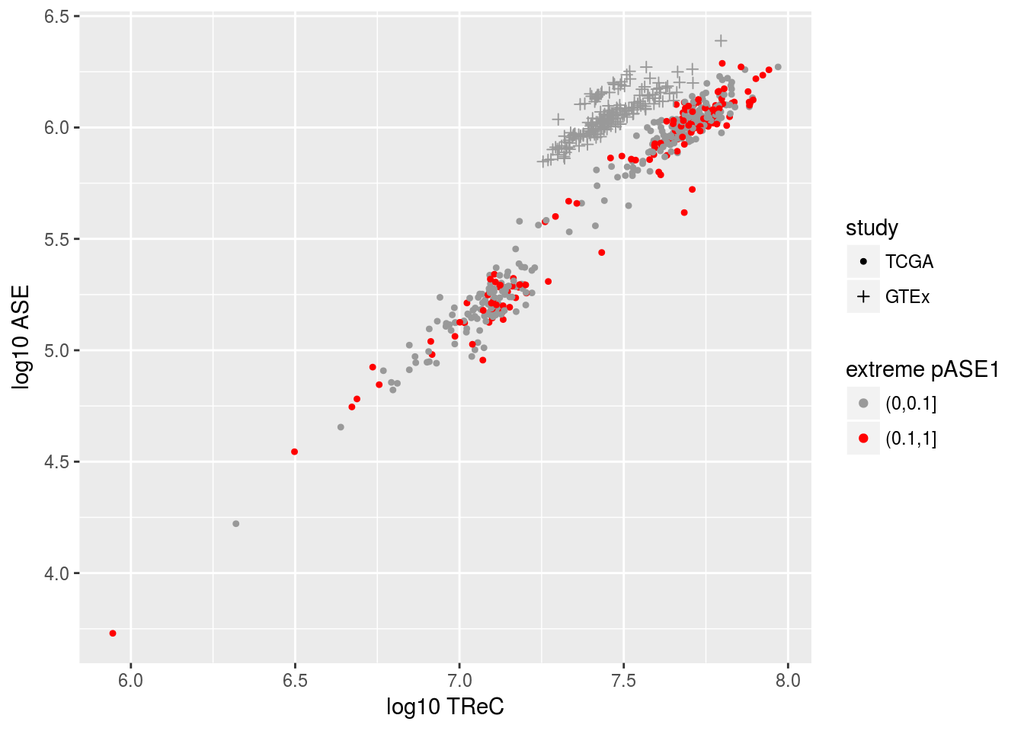

```r
ggplot(plot_data_all, aes(log10TReCt, log10ASEt,
       shape = study,
       color = cut(pASE1_bi0.1, breaks = c(0, 0.1, 1)))) +
  geom_point() + labs(color = 'extreme pASE1', x = 'log10 TReC', y = 'log10 ASE') +
  scale_shape_manual(values=c(20, 3), name = 'study') +
  scale_color_manual(values=c('#999999','red'))
```

```r
het_getx = "/fh/fast/sun_w/licai/_GTEx/data_genotype/data_snp/cgc_snpfile/"
het_tcga = "/fh/fast/sun_w/licai/_tumor_eQTL/data_snp/"

files = list.files(het_tcga, "combined.txt", recursive = T)
tmp1 = matrix(NA, nrow = length(files), ncol =1)
rownames(tmp1) = list.files(het_tcga, "TCGA")

for(filei in rownames(tmp1)){
  tmp1[filei, ] = system(paste0("wc -l ",het_tcga,filei,
                             "/combined.txt"), intern = T)
}

tmp1[,1] = as.numeric(sapply(strsplit(tmp1, " "), "[",1))
tcga_nhet = as.numeric(tmp1)
names(tcga_nhet) = rownames(tmp1)
tcga_nhet[1:5]
```

```
## TCGA-3L-AA1B TCGA-4N-A93T TCGA-4T-AA8H TCGA-5M-AAT4 TCGA-5M-AAT5
##      6246504      6272990      6248535      6219487      6337627
```

```r
hist(tcga_nhet)

tmp1 = system(paste0("wc -l ",het_getx, "*"), intern = T)
tmp1 = strsplit(tmp1, " ")
tmp1[1:3]
```

[output not shown]

```
## [[1]]
## [1] ""
## [2] ""
## [3] ""
## [4] "1977801"
## [5] "/fh/fast/sun_w/licai/_GTEx/data_genotype/data_snp/cgc_snpfile/GTEX-111CU.txt"
##
## [[2]]
## [1] ""
## [2] ""
## [3] ""
## [4] "1938027"
## [5] "/fh/fast/sun_w/licai/_GTEx/data_genotype/data_snp/cgc_snpfile/GTEX-111VG.txt"
##
## [[3]]
## [1] ""
## [2] ""
## [3] ""
## [4] "1933360"
## [5] "/fh/fast/sun_w/licai/_GTEx/data_genotype/data_snp/cgc_snpfile/GTEX-111YS.txt"
```

```r
tmp1[length(tmp1)]
```

```
## [[1]]
## [1] ""          "509075338" "total"
```

```r
tmp1 = tmp1[-length(tmp1)]
tmp2 = sapply(tmp1, "[", 5)
tmp2 = gsub("/fh/fast/sun_w/licai/_GTEx/data_genotype/data_snp/cgc_snpfile/",
            "", tmp2)
tmp2 = gsub(".txt", "", tmp2)
tmp2[1:5]
```

```
## [1] "GTEX-111CU" "GTEX-111VG" "GTEX-111YS" "GTEX-1122O" "GTEX-1128S"
```

```r
gtex_nhet = as.numeric(sapply(tmp1, "[", 4))
names(gtex_nhet) = tmp2
gtex_nhet[1:5]
```

```
## GTEX-111CU GTEX-111VG GTEX-111YS GTEX-1122O GTEX-1128S
##    1977801    1938027    1933360    1947559    1957831
```

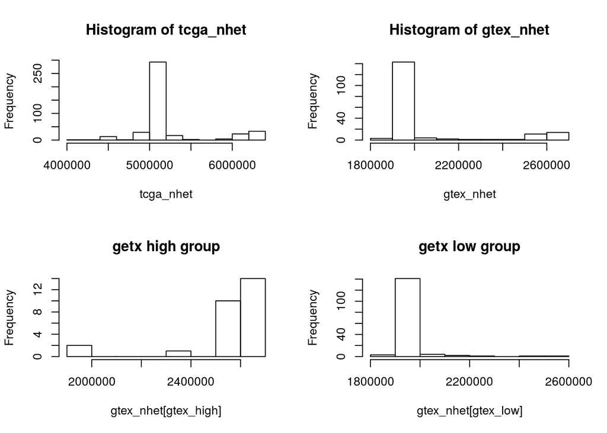

```r
gtex_nhet = gtex_nhet[rownames(plot_data2)]

gtex_high = rownames(plot_data_all[which(plot_data_all$n_gene_ASE_per_sam >= 7000),])
gtex_low = rownames(plot_data_all[which(plot_data_all$n_gene_ASE_per_sam < 7000 &
                                           plot_data_all$study == "GTEx"),])

par(mfrow=c(2,2))
hist(tcga_nhet)
hist(gtex_nhet)
hist(gtex_nhet[gtex_high], main = "getx high group")
hist(gtex_nhet[gtex_low], main = "getx low group")
```

```r
par(mfrow=c(1,1))
```